# Estadística descriptiva con datos ordinales

Ramon Ceballos

29/1/2021

# 1. Descripción de datos ordinales

Los **datos ordinales** son parecidos a los cualitativos, en el sentido de que son cualidades de los individuos u objetos.

La diferencia existente entre los datos cualitativos y los ordinales reside en las características que expresan. En el caso de los ordinales, éstas tienen un orden natural que permite “acumular” observaciones.

Es decir, podemos contar, para cada nivel, cuantas veces hemos observado un dato menor o igual a este.

Un ejemplo frecuente de datos ordinales es el empleo de las **Escalas Likert**.

# 2. Frecuencias para datos ordinales

Al trabajar con datos ordinales, el orden de los niveles de los datos nos permite calcular no solo *frecuencias absolutas y relativas*, sino también **frecuencias acumuladas**.

Es decir, podemos contar cuantas veces hemos observado un dato menor o igual a este.

### Ejemplo 1

Suponed que tenemos una muestra de 15 estudiantes de los cuales sabemos su nota en el examen de Estadística. Clasificamos todos estos resultados en Suspenso ($S$), Aprobado ($A$), Notable ($N$) y Excelente ($Ex$) y consideramos su orden natural $S<A<N<Ex$.

Las notas obtenidas han sido las siguientes
$$S,\ A,\ N,\ Ex,\ S,\ S,\ Ex,\ Ex,\ N,\ A,\ A,\ A,\ A,\ N,\ S$$
Como recordaréis, para saber cuantas hay de cada una (su frecuencia absoluta), utilizamos la función **`table()`**.

Para crear el array de datos ordinales se emplea la función **ordered()** en lugar de factor().

```r
#Creo el array de notas
#En vez de emplear la función factor(),
#se emplea la función ordered() para generar el array de datos ordinales
notas = ordered(c("S","A", "N", "Ex",
                  "S", "S", "Ex", "Ex",
                  "N", "A", "A",
                  "A","A", "N", "S"),
        levels = c("S", "A", "N", "Ex"))

#Genero la table contingencia para esta variable ordinal
table(notas)
```

```
## notas
##  S  A  N Ex
##  4  5  3  3
```

Como podréis observar, hay 4 $S$, 5 $A$, 3 $N$ y 3 $Ex$.

En lo referente a **frecuencias absolutas acumuladas**, hay

- 4 estudiantes con $S$ o menos. Ello implica que la frecuencia acumulada de $S$ es 4
- 9 estudiantes que han obtenido $A$ o menos. Entonces, la frecuencia acumulada de $A$ es 9
- 12 estudiantes los cuales han obtenido $N$ o menos. Así, la frecuencia acumulada de $N$ es 12
- 15 estudiantes (todos) que han obtenido $Ex$ o menos. De este modo, la frecuencia acumulada de $Ex$ es 15, o sea, el total.

**Frecuencia relativa acumulada.** Es la fracción del total de las observaciones en tanto por 1 que representa su frecuencia absoluta acumulada

Así, las recuencias relativas acumuladas respectivas son

- $S:\ \frac{4}{15} \approx$ 0.27
- $A:\ \frac{9}{15}\approx$ 0.6
- $N:\ \frac{12}{15}\approx$ 0.8
- $Ex:\ \frac{15}{15}=1$

En general, supongamos que realizamos $n$ observaciones:

$$x_1,\dots,x_n$$
Estas observaciones son de un cierto tipo de datos ordinales, cuyos posibles niveles ordenados son:

$$l_1<l_2<\dots<l_k$$
Por tanto, cada una de las observaciones $x_j$ es igual a algún $l_i$. Diremos que todas estas observaciones forman una variable ordinal. En nuestro ejemplo anterior, los 4 niveles eran:
$$S<A<N<Ex$$

Además, nuestro $n = 15$ y nuestros $x_1,\dots,x_{15}$ son las calificaciones obtenidas por los alumnos.

De este modo, con estas notaciones

- Las definiciones de **frecuencias absolutas** $n_j$ y las **relativas** $f_j$, para cada nivel $l_j$ son las mismas que en una variable cualitativa.
- Las **frecuencia absoluta acumulada** del nivel $l_j$ en esta variable ordinal es el número $N_j$ de observaciones $x_i$ tales que $x_i\le l_j$. Es decir,
  $$N_j=\sum_{i=1}^jn_i$$
- La **frecuencia relativa acumulada** del nivel $l_j$ en esta variable ordinal es la fracción en tanto por 1 $F_j$ de observaciones $x_i$ tales que $x_i\le l_j$. Es decir,
  $$F_j=\frac{N_j}{n}=\sum_{i=1}^jf_i$$

### Ejemplo 2

En un estudio, a un grupo de clientes de un restaurante, se les hizo la siguiente pregunta:

“¿Estás contento con el trato ofrecido por los trabajadores del establecimiento?”

Las posibles respuestas forman una escala ordinal con $1<2<3<4<5$. El valor 1 se corresponde con un trato malo por parte de los trabajadores minetras que el valor 5 refiere a un trato excelente.

Supongamos que se recogieron las siguientes respuestas de 50 técnicos:

```r
#set.seed() permite que cada vez que se ejecuten las líneas salgan los mismo resultados
#Se pone un nº facil de recordar
set.seed(2018)

#sample() genera un array aleatorio
clientes = sample(1:5, 50, replace = TRUE)
clientes
```

```
##  [1] 3 4 5 2 5 1 3 4 2 4 3 3 1 1 5 3 1 3 3 5 1 4 2 5 3 4 5 1 2 2 1 5 5 2 1 2 5 5
## [39] 2 1 2 1 3 2 1 2 3 3 1 2
```

```r
#Permite que la semilla aleatoria vuelva a partir de cero
set.seed(NULL)
```

En este caso tenemos 5 niveles ($k=5$) y 50 observaciones ($n=50$) que forman una variable ordinal a la que hemos llamado `clientes`.

Hemos calculado todas sus frecuencias (absoluta, relativa, acumulada y relativa acumulada) y las hemos representado en la siguiente tabla.

```r
#FREC. ABSOLUTA
absolut = table(clientes)

#FREC. RELATIVA ABSOLUTA
relative = prop.table(absolut)

#FREC. ABSOLUTA ACUMULADA
acumul = cumsum(absolut)

#FREC. RELATIVA ACUMULADA
rel.acumul = cumsum(relative)


#Guardo todas las frecuencias en una misma tabla

absolut = (as.matrix(absolut))
relative = (as.matrix(relative))
acumul = (as.matrix(acumul))
rel.acumul = (as.matrix(rel.acumul))

clientela = data.frame(absolut,relative,acumul,rel.acumul)

colnames(clientela) = c("Absoluta", "Relativa", "Acumulada", "Rel. Acumulada")

clientela
```

|  | Absoluta | Relativa | Acumulada | Rel. Acumulada |
| --- | --- | --- | --- | --- |
| 1 | 12 | 0.24 | 12 | 0.24 |
| 2 | 12 | 0.24 | 24 | 0.48 |
| 3 | 11 | 0.22 | 35 | 0.70 |
| 4 | 5 | 0.10 | 40 | 0.80 |
| 5 | 10 | 0.20 | 50 | 1.00 |

Los gráficos para frecuencias absolutas y relativas absolutas de variables ordinales son exactamente los mismos que para las variables cualitativas.

También podemos utilizar diagramas de barras para describir frecuencias acumuladas: en este caso, la altura de cada barra debe ser igual a la frecuencia acumulada del nivel respectivo. Además, estos niveles deben de aparecer ordenados de manera ascendente, de forma que las alturas de las barras también tengan un orden ascendente.

No obstante, se recomienda no hacer uso de diagramas circulares a la hora de representar frecuencias acumuladas, debido a que éstos no representan la información sobre la acumulación de datos de forma fácil de entender a simple vista.

## 2.1. Frecuencias Acumuladas (absolutas y relativas)

**Función cumsum()**

¿Recordáis la función `cumsum()`? Pues esta puede ser utilizada a la hora de calcular frecuencias acumuladas. Para obtenerlas se hace:

- Frecuencias absolutas acumuladas.Se aplica cumsum() a la tabla de frecuencias absolutas.
- Frecuencias relativas globales acumuladas.Se aplica cumsum() a la tabla de frecuencias relativas globales

Retomemos el ejemplo anterior de las notas de los estudiantes y calculemos y representemos en un diagrama de barras las frecuencias acumuladas de la muestra de notas.

```r
#Vector de estudio
notas
```

```
##  [1] S  A  N  Ex S  S  Ex Ex N  A  A  A  A  N  S
## Levels: S < A < N < Ex
```

```r
#Calculo de Frec. abs.
fAbs = table(notas)

#Calculo de Frec. abs. acumuladas
cumsum(fAbs)
```

```
##  S  A  N Ex
##  4  9 12 15
```

```r
#calculo de Frec. relativas acumuladas
cumsum(prop.table(fAbs))
```

```
##         S         A         N        Ex
## 0.2666667 0.6000000 0.8000000 1.0000000
```

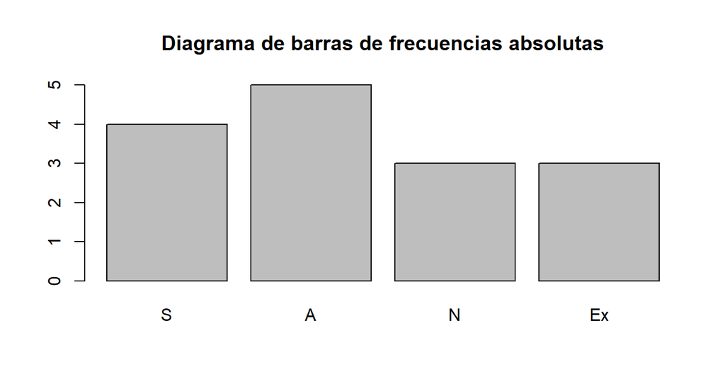

```r
#Diagrama de barras para las frec. absolutas
barplot(fAbs, main = "Diagrama de barras de frecuencias absolutas")
```

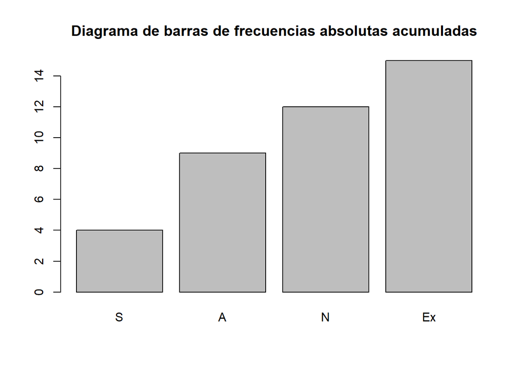

```r
#Diagrama de barras para las frec. absolutas acumuladas
barplot(cumsum(fAbs), main = "Diagrama de barras de frecuencias absolutas acumuladas")
```

Podríamos haber calculado las frecuencias relativas acumuladas de la siguiente forma.

```r
#dividir las frecuencias absolutas acumuladas por la longitud del vector
cumsum(table(notas))/length(notas)
```

```
##         S         A         N        Ex
## 0.2666667 0.6000000 0.8000000 1.0000000
```

```r
#hacer cumsum() de las frecuencias relativas globales
cumsum(table(notas)/length(notas))
```

```
##         S         A         N        Ex
## 0.2666667 0.6000000 0.8000000 1.0000000
```

Pero no podemos hacer `prop.table(cumsum(table(notas)))`. Da un valor incorrecto ya que toma la tabla de frecuencias absolutas acumuladas como una tabla de contingencia.

### Ejemplo 3

Se ha evaluado el tamaño de los cuellos de 100 jirafas. Los niveles que se han utilizado se los considera ordenados de la siguiente manera:

$$\text{Muy.corto}<\text{Corto}<\text{Normal}<\text{Largo}<\text{Muy.largo}$$

Los valores obtenidos en dicho estudio han sido los siguientes:

```r
set.seed(2018)

longitud = sample(1:5,100, replace = TRUE)

longitud = ordered(longitud)

levels(longitud) = c("Muy.corto","Corto","Normal","Largo","Muy.largo")
```

```r
#vector a estudiar del cuello de las jirafas
longitud
```

```
##   [1] Normal    Largo     Muy.largo Corto     Muy.largo Muy.corto Normal
##   [8] Largo     Corto     Largo     Normal    Normal    Muy.corto Muy.corto
##  [15] Muy.largo Normal    Muy.corto Normal    Normal    Muy.largo Muy.corto
##  [22] Largo     Corto     Muy.largo Normal    Largo     Muy.largo Muy.corto
##  [29] Corto     Corto     Muy.corto Muy.largo Muy.largo Corto     Muy.corto
##  [36] Corto     Muy.largo Muy.largo Corto     Muy.corto Corto     Muy.corto
##  [43] Normal    Corto     Muy.corto Corto     Normal    Normal    Muy.corto
##  [50] Corto     Normal    Muy.corto Largo     Largo     Corto     Muy.corto
##  [57] Corto     Normal    Normal    Normal    Normal    Muy.corto Normal
##  [64] Muy.corto Corto     Largo     Muy.corto Corto     Muy.corto Muy.largo
##  [71] Muy.corto Corto     Muy.largo Largo     Muy.largo Normal    Corto
##  [78] Corto     Normal    Largo     Largo     Corto     Corto     Muy.largo
##  [85] Largo     Largo     Normal    Normal    Muy.corto Normal    Corto
##  [92] Normal    Muy.corto Corto     Muy.corto Normal    Corto     Corto
##  [99] Muy.corto Corto
## Levels: Muy.corto < Corto < Normal < Largo < Muy.largo
```

```r
set.seed(NULL)
```

Estudiemos las frecuencias absolutas y relativas del vector del ejemplo.

```r
#frec. abs.
Fr.Abs = table(longitud)
Fr.Abs
```

```
## longitud
## Muy.corto     Corto    Normal     Largo Muy.largo
##        23        26        24        13        14
```

```r
#frec. rel. global
Fr.Rel = prop.table(Fr.Abs)
Fr.Rel
```

```
## longitud
## Muy.corto     Corto    Normal     Largo Muy.largo
##      0.23      0.26      0.24      0.13      0.14
```

```r
#frec. abs. acumuladas
Fr.Acum = cumsum(Fr.Abs)
Fr.Acum
```

```
## Muy.corto     Corto    Normal     Largo Muy.largo
##        23        49        73        86       100
```

```r
#frec. rel. acumuladas
Fr.RAcum = cumsum(Fr.Rel)
Fr.RAcum
```

```
## Muy.corto     Corto    Normal     Largo Muy.largo
##      0.23      0.49      0.73      0.86      1.00
```

La instrucción `barplot` produce el siguiente diagrama de barras de frecuencias relativas acumuladas.

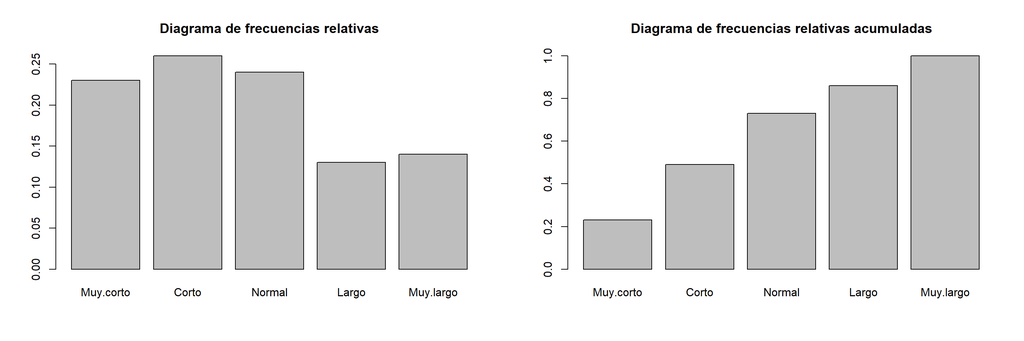

```r
par(mfrow=c(1,2))

barplot(Fr.Rel, main = "Diagrama de frecuencias relativas")

barplot(Fr.RAcum, main = "Diagrama de frecuencias relativas acumuladas")
```

```r
par(mfrow=c(1,1))
```

La instrucción `barplot` produce el siguiente diagrama de barras de frecuencias absolutas acumuladas.

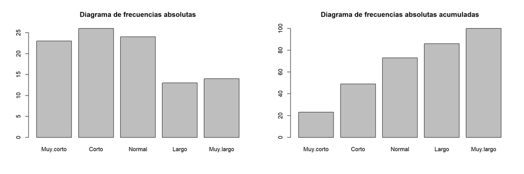

```r
par(mfrow=c(1,2))

barplot(Fr.Abs, main = "Diagrama de frecuencias absolutas")

barplot(Fr.Acum, main = "Diagrama de frecuencias absolutas acumuladas")
```

```r
par(mfrow=c(1,1))
```